# Сетевые технологии

Лабораторная работа №5

Элсаиед Адел

Российский университет дружбы народов, Москва, Россия

20 января 2026

# Цели и задачи работы

## Цель лабораторной работы

Построение простейших моделей сети в **GNS3**: - сеть на базе **Ethernet-коммутатора** и двух VPCS - сеть на базе маршрутизатора **FRR** + коммутатор + VPCS - сеть на базе маршрутизатора **VyOS** + коммутатор + VPCS

Дополнительно: - захват и анализ трафика в **Wireshark** - изучение протоколов **ARP** и **ICMP**, а также режимов эхо-запросов **ICMP/UDP/TCP**

# Ход выполнения работы

## Топология (коммутатор + 2 ПК)

- Коммутатор: `msk-elsaiedadel-sw-01`
- Узлы: `PC1-elsaiedadel`, `PC2-elsaiedadel`
- Соединение VPCS ↔︎ switch, отображение интерфейсов включено

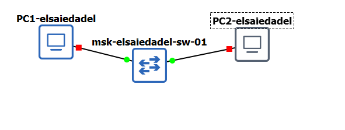

Топология сети на базе коммутатора

## Настройка VPCS и проверка связи

- На VPCS просмотрена справка команд (проверка синтаксиса)
- Задана IP-адресация в `192.168.1.0/24`

[figure not shown]

Справка команд VPCS

## Настройка VPCS и проверка связи

- Связность проверена `ping` между узлами

[figure not shown]

Проверка связи PC1 ↔︎ PC2

## Запуск захвата и ARP (Gratuitous ARP)

- Захват включён на линии **PC1 ↔︎ switch**
- При старте узлов фиксируются ARP-кадры
- Наблюдаются **Gratuitous ARP** для объявления адреса и проверки конфликтов

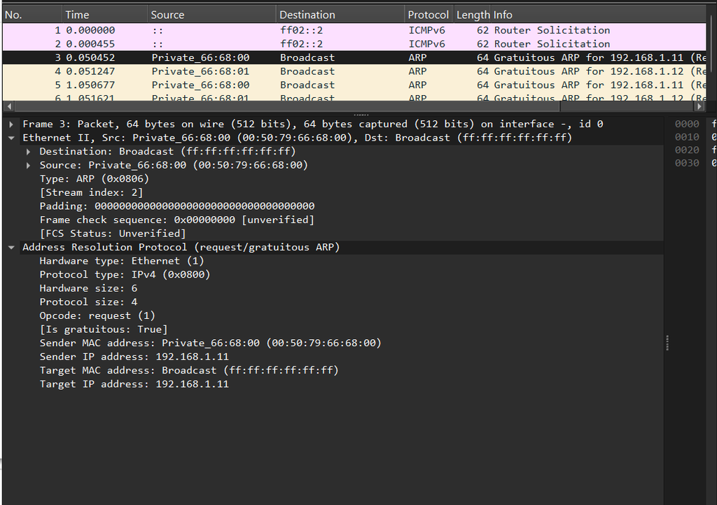

ARP-трафик в Wireshark

## ICMP Echo (ping) — запрос и ответ

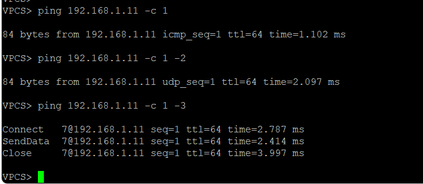

ICMP эхо-запрос и ответ

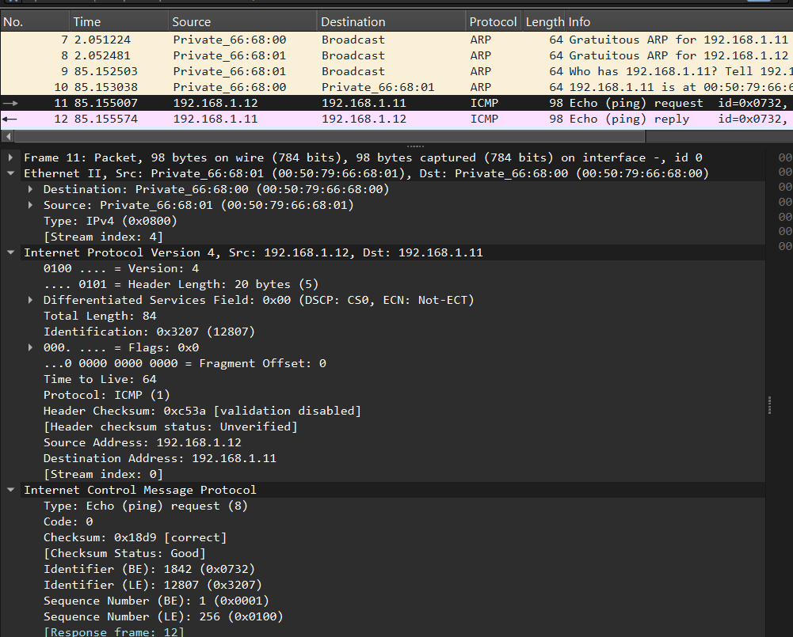

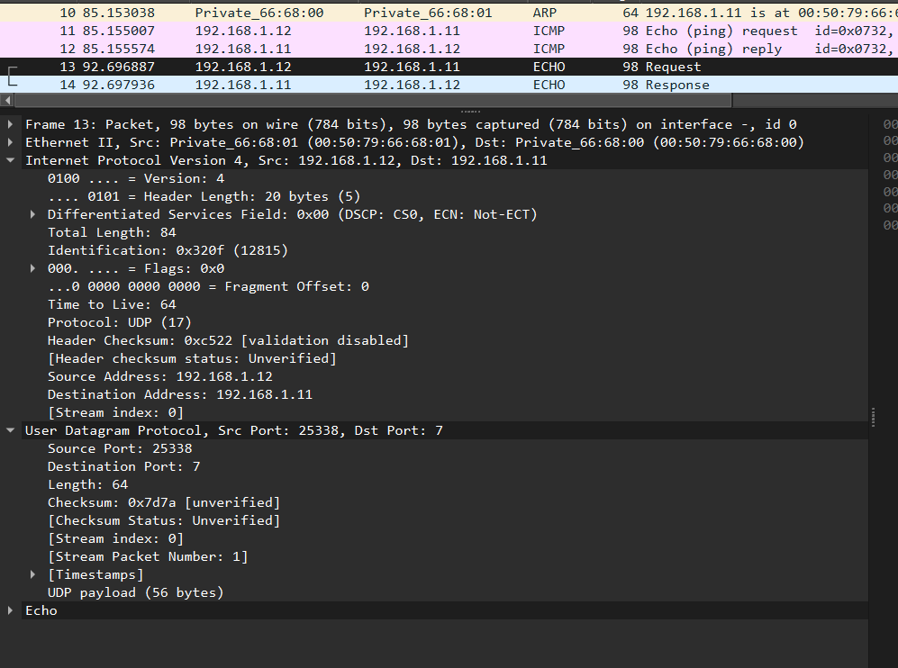

## Топология (FRR + switch + ПК)

- `PC1-elsaiedadel` ↔︎ `msk-elsaiedadel-sw-01` ↔︎ `msk-elsaiedadel-gw-01`
- Захват трафика включён на линии **switch ↔︎ FRR**

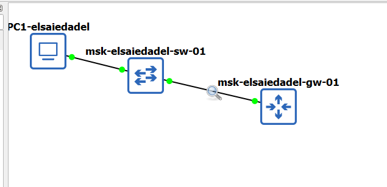

Топология сети с FRR

## Настройка IP на PC1

- Адрес узла: `192.168.1.10/24`
- Шлюз: `192.168.1.1`
- Конфигурация сохранена, параметры проверены

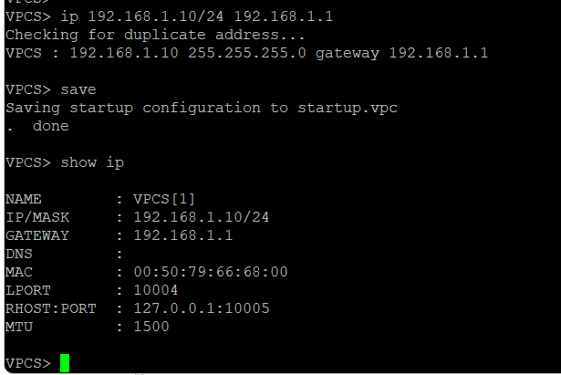

Настройка IP на VPCS

## Настройка FRR (eth0 = 192.168.1.1/24)

- Установлен hostname: `msk-elsaiedadel-gw-01`
- На `eth0` задан адрес `192.168.1.1/24`
- Конфигурация сохранена

[figure not shown]

Конфигурация интерфейса FRR

## Проверка конфигурации FRR

- Просмотр конфигурации и статуса интерфейсов
- Подтверждено состояние интерфейса `eth0` (up) и корректный адрес

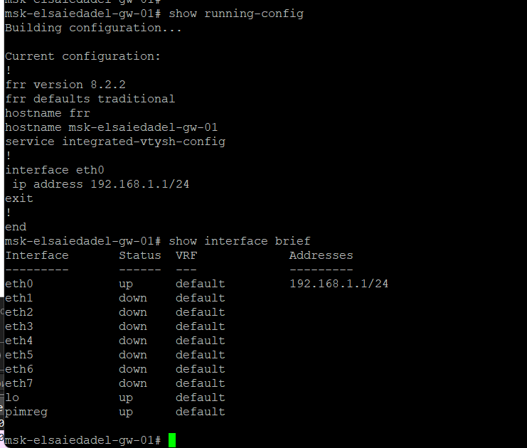

Проверка running-config и interface brief

## Проверка связи и анализ трафика

- С `PC1` выполнен `ping` на `192.168.1.1`

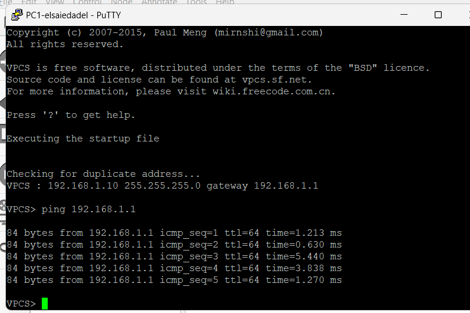

Ping PC → FRR

## Проверка связи и анализ трафика

- В Wireshark фиксируются ARP и ICMP пакеты между узлом и маршрутизатором

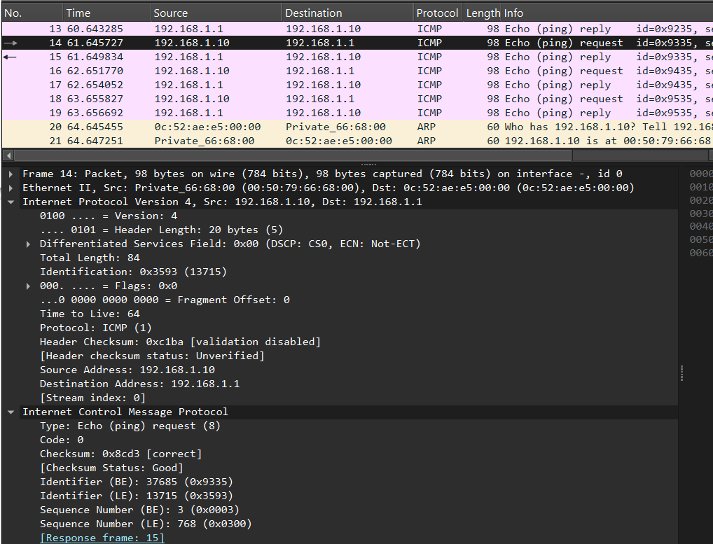

ARP и ICMP трафик (PC ↔︎ FRR)

## Топология (VyOS + switch + ПК)

- `PC1-elsaiedadel` ↔︎ `msk-elsaiedadel-sw-01` ↔︎ `msk-elsaiedadel-gw-01`
- Захват трафика включён на линии **switch ↔︎ VyOS**

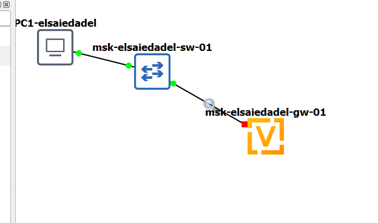

Топология сети с VyOS

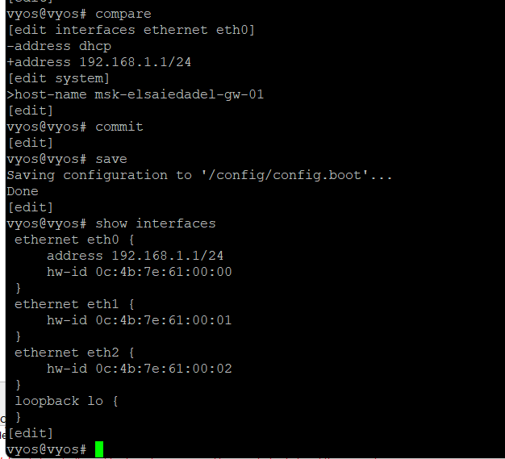

## Настройка VyOS (host-name и eth0)

- В режиме конфигурирования:
  - host-name: `msk-elsaiedadel-gw-01`
  - `eth0`: `192.168.1.1/24`
- Изменения применены `commit` и сохранены `save`
- Проверены интерфейсы (`show interfaces`)

[figure not shown]

## Проверка связи и анализ трафика

- С `PC1` выполнен `ping` на `192.168.1.1`
- В Wireshark наблюдаются ARP и ICMP кадры при установлении взаимодействия

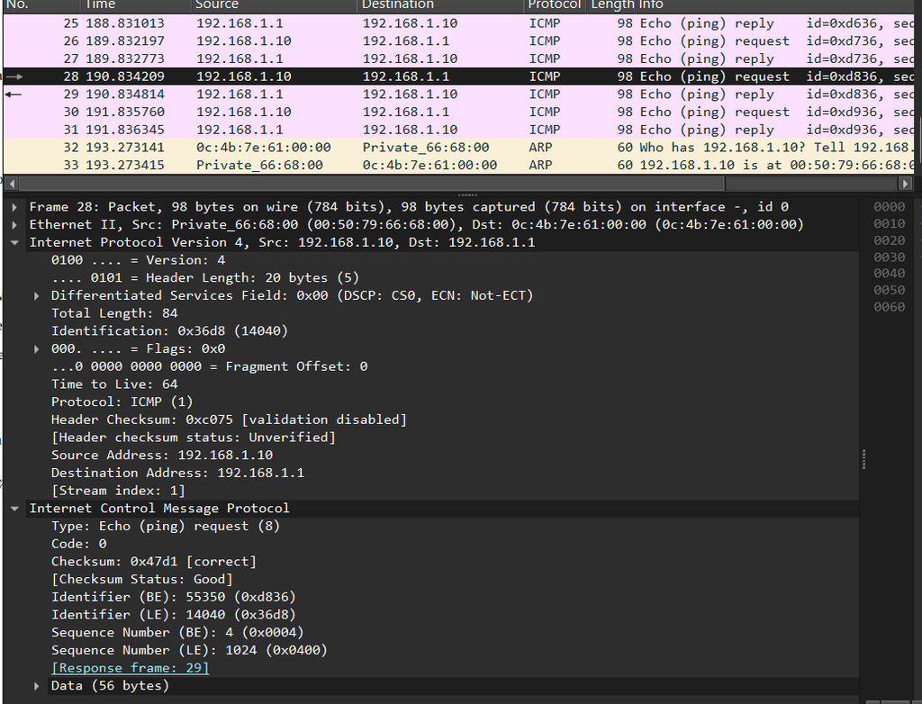

Ping PC → VyOS

# Итоги

## Заключение

- Построены и проверены три простые модели сети в **GNS3**:
  - коммутатор + 2 VPCS
  - FRR + коммутатор + VPCS
  - VyOS + коммутатор + VPCS
- Настроена IP-адресация в `192.168.1.0/24`, проверена связность `ping`
- Выполнен захват и анализ трафика в **Wireshark**
- На практике изучены:
  - **ARP** (включая Gratuitous ARP)
  - **ICMP Echo Request/Reply**
  - особенности эхо-запросов в режимах **ICMP/UDP/TCP**